# Case Study 2 - Employee Turnover Analysis

## Executive Summary

### Background:

- Frito-Lay is always about people; it is a place that seeks out different perspectives and celebrates diversity at every level of the organization
- Frito-Lay has engaged DDSAnalytics to leverage data science and take the Talent Management to next level
- Scope of services includes workforce planning, employee training, and reducing/preventing voluntary employee turnover

### Objectives:

1. Identify the top three factors that contribute to employee turnover
2. Build a robust model to predict attrition
3. Obtain job role specific insights that will help with employee retention, satisfaction, and professional development

## Preparation

First, we will import the dataset provided. There are some variables in the dataset that contain same value for all the observations - these variables will cause us issues when we try to calculate correlations. So we will remove these variables from the dataset. Then we will check if any of the variables contain missing values.

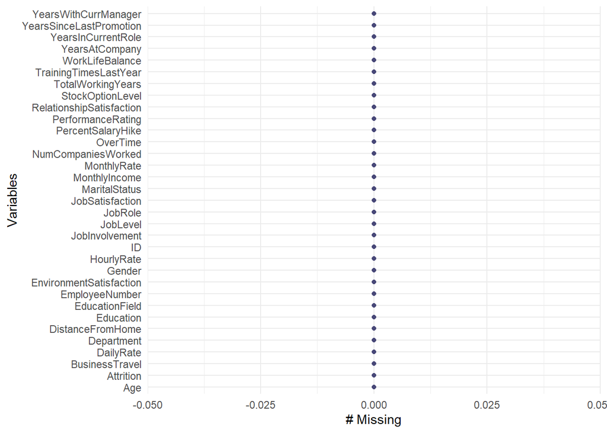

All the variables contain values for all the observations. We will now continue with data exploration for variables selection.

## Data Exploration

We will do the following to identify the variables influencing attrition.

1. Assess the correlation of various factor variables on attrition - we will do this by plotting percentage stacked bars for attrition for different values of factors to see if any specific values of the factor influence the attrition.
2. Assess the correlation of various continuous variables on attrition - we will use overlayed histograms to assess if we can identify the data ranges of the variable that influence attrition.
3. Obtain correlation coefficients for the relevant variables - we will run correlation test and use estimates to assess the correlation.
4. Identify the set of variables that impact attrition - we will use the results from above 3 steps for this.

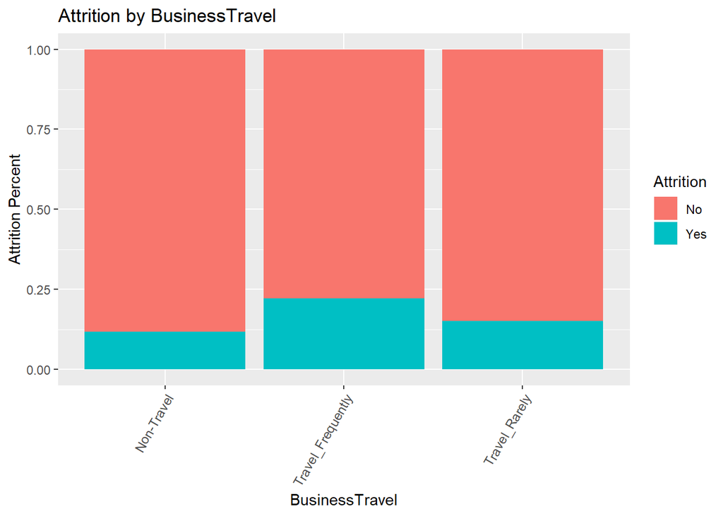

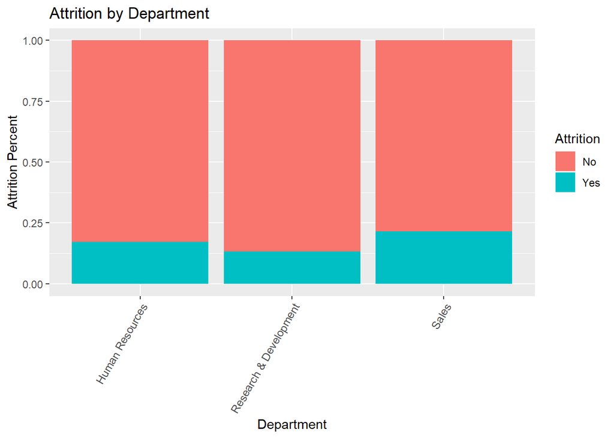

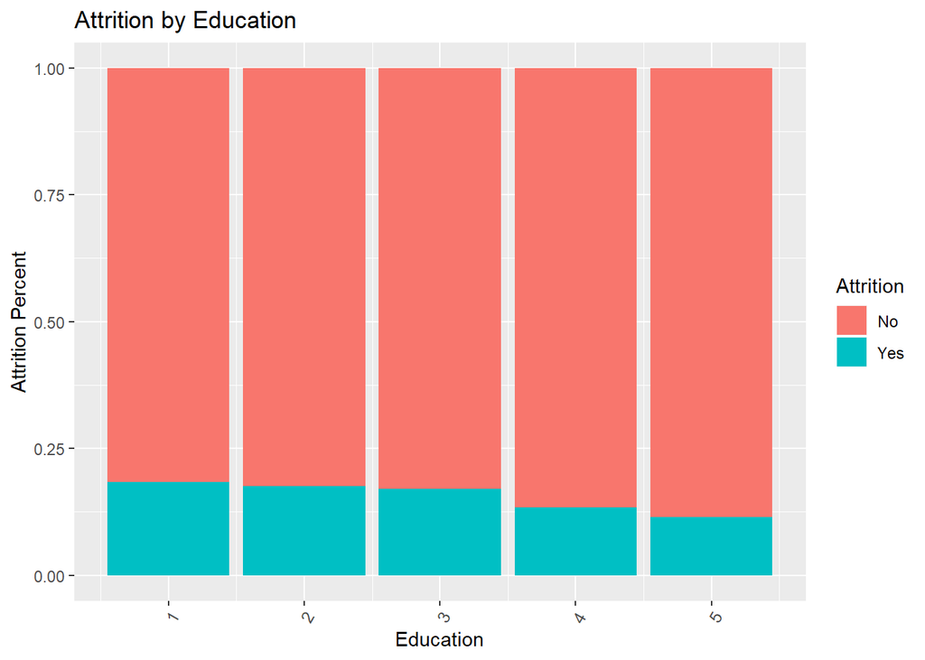

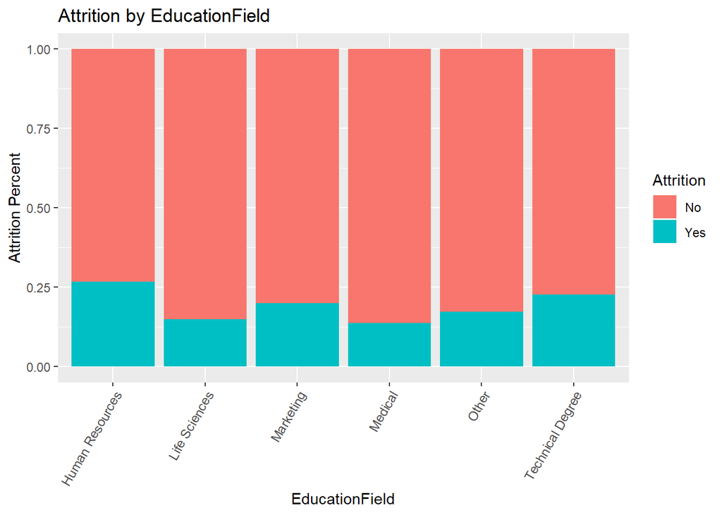

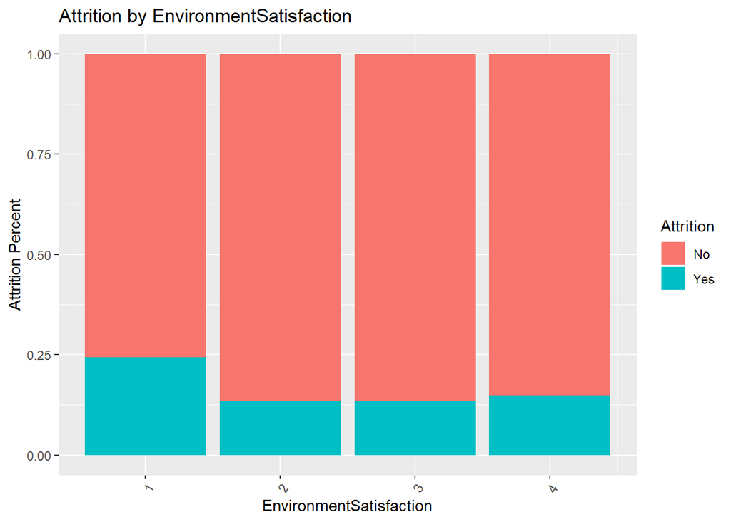

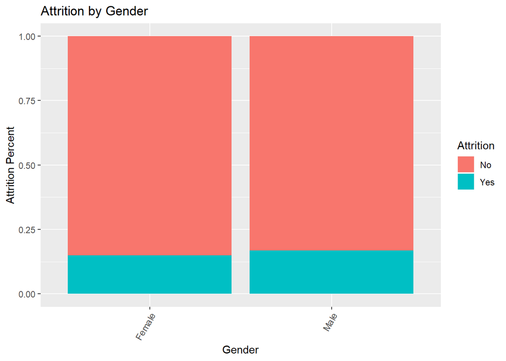

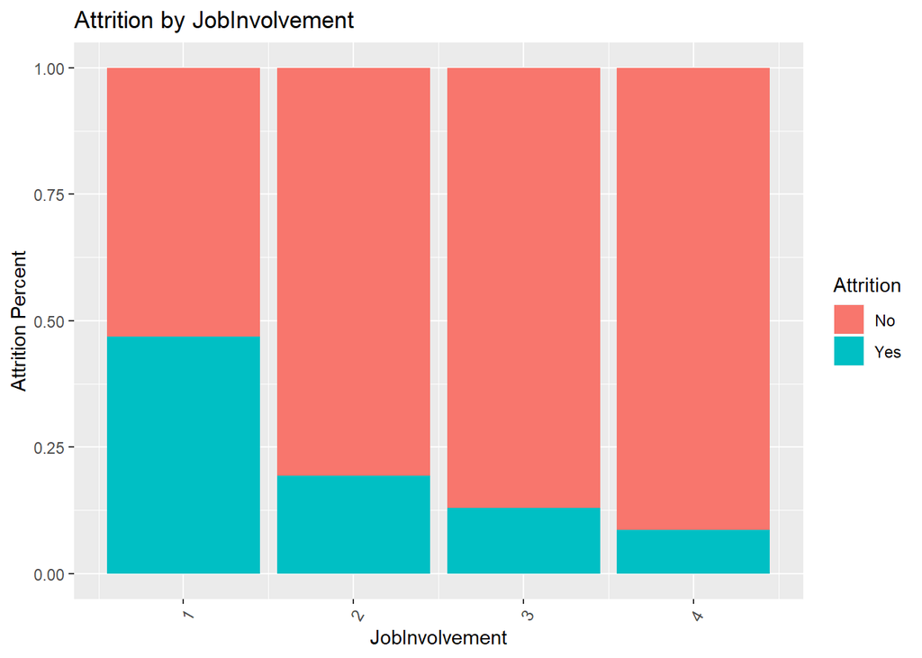

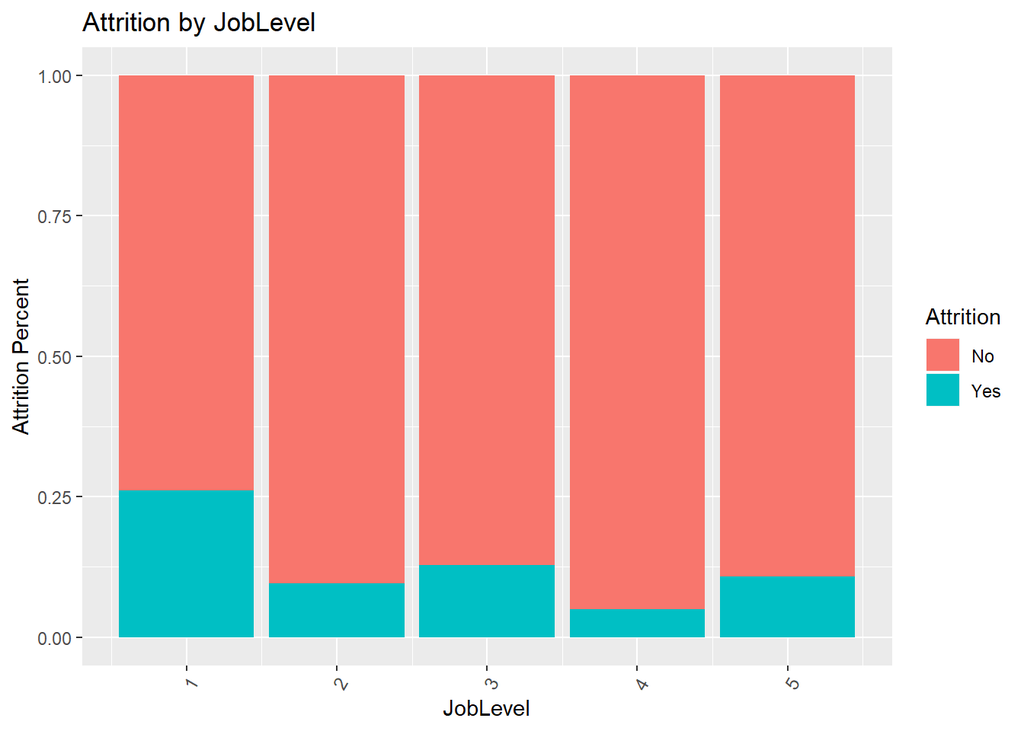

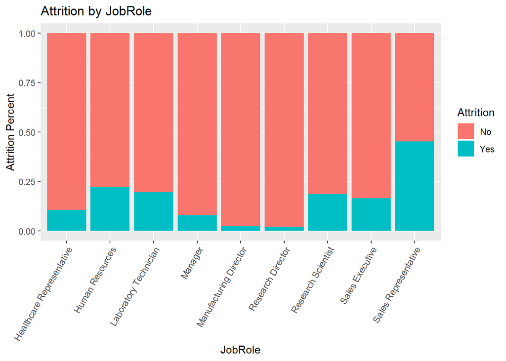

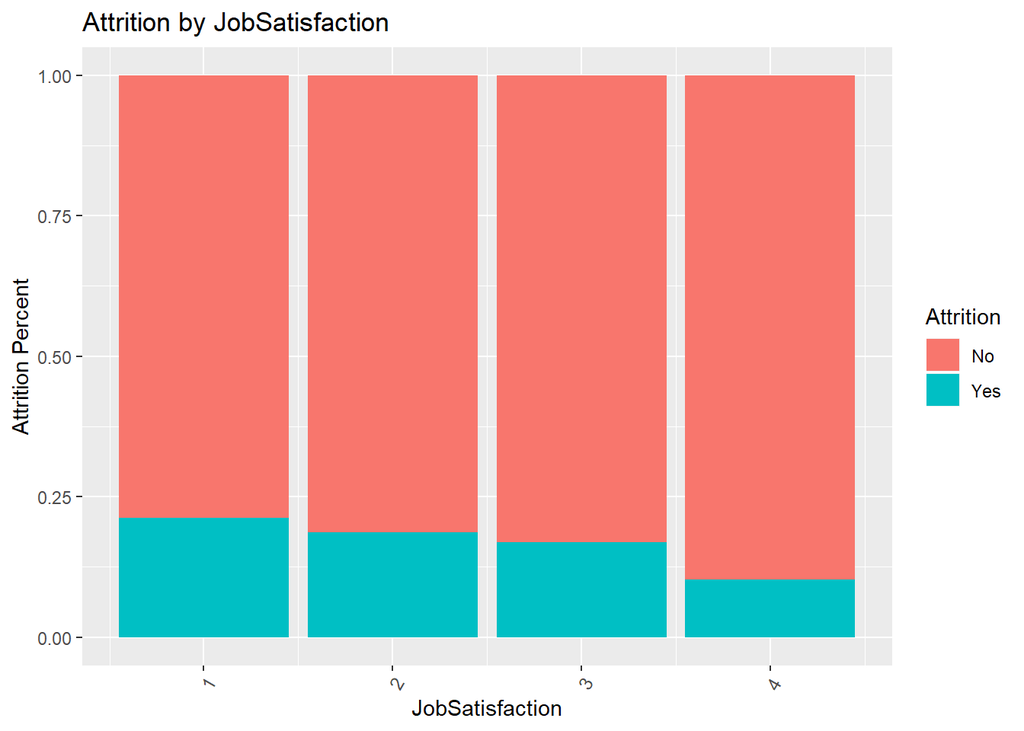

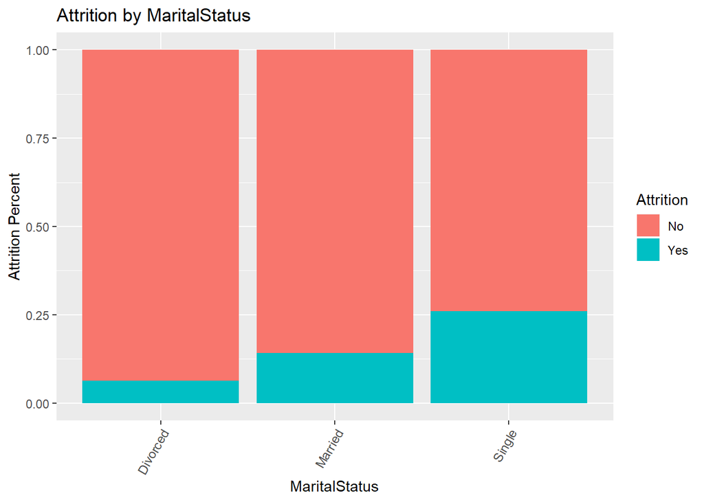

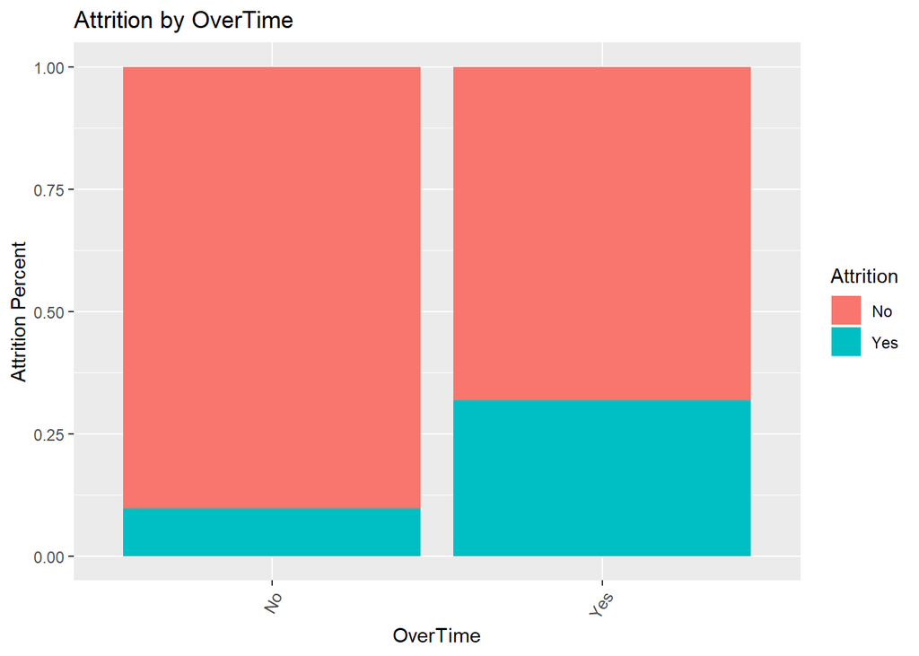

[5 more figures not shown]

Based on the above stacked bars, we infer that the following factors potentially influence the attrition: EnvironmentSatisfaction, JobInvolvement, JobLevel, JobRole, MaritalStatus, OverTime, StockOptionLevel, WorkLifeBalance

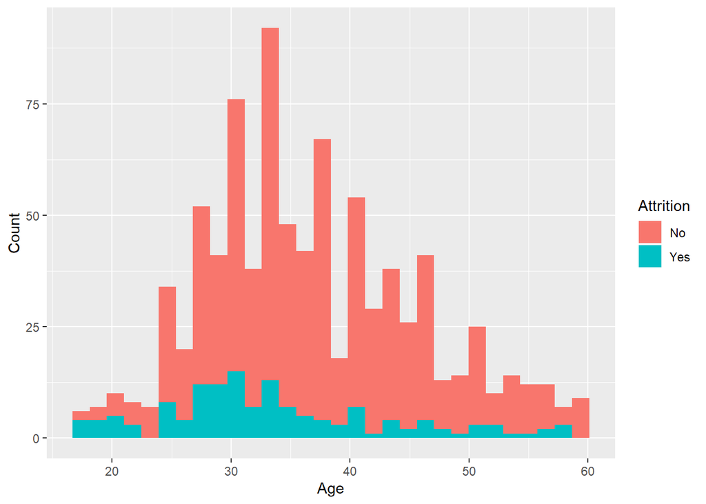

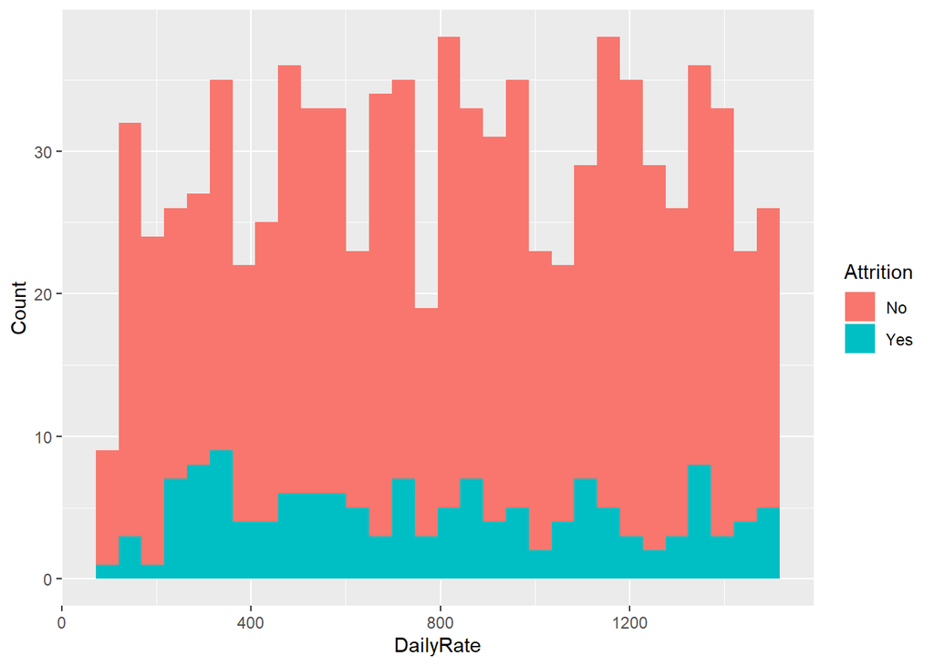

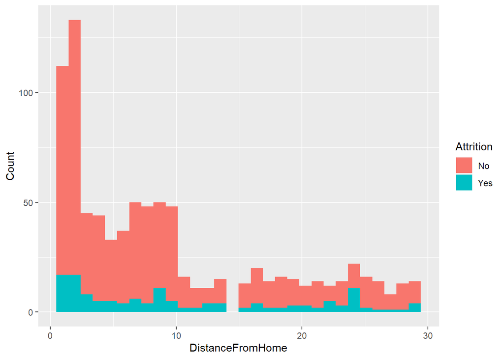

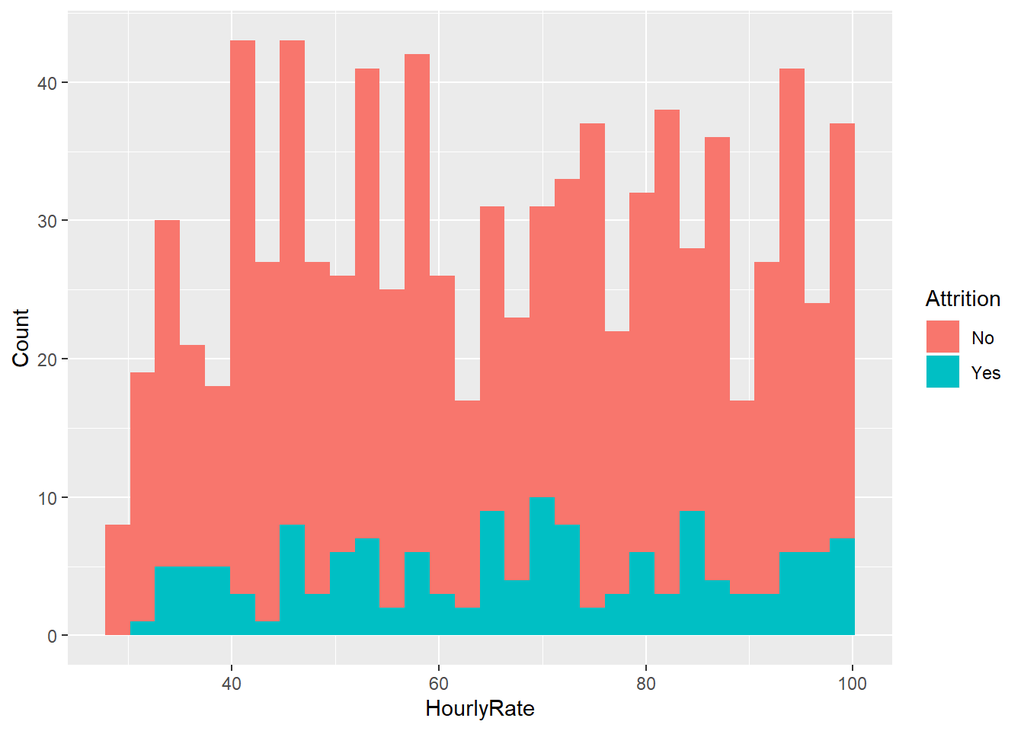

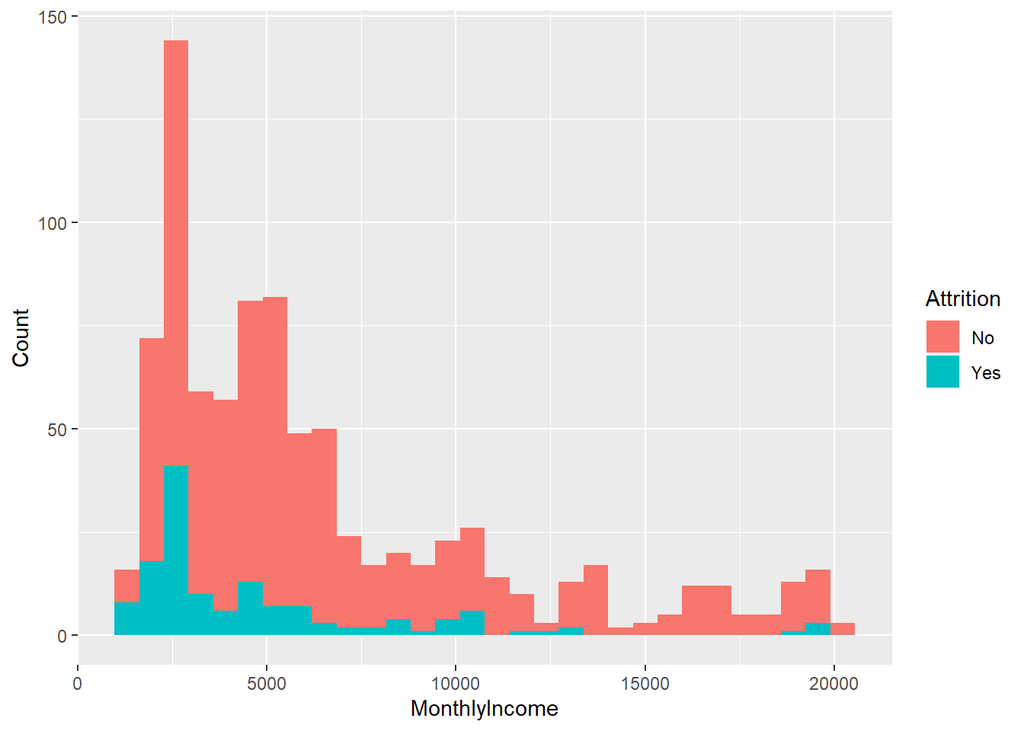

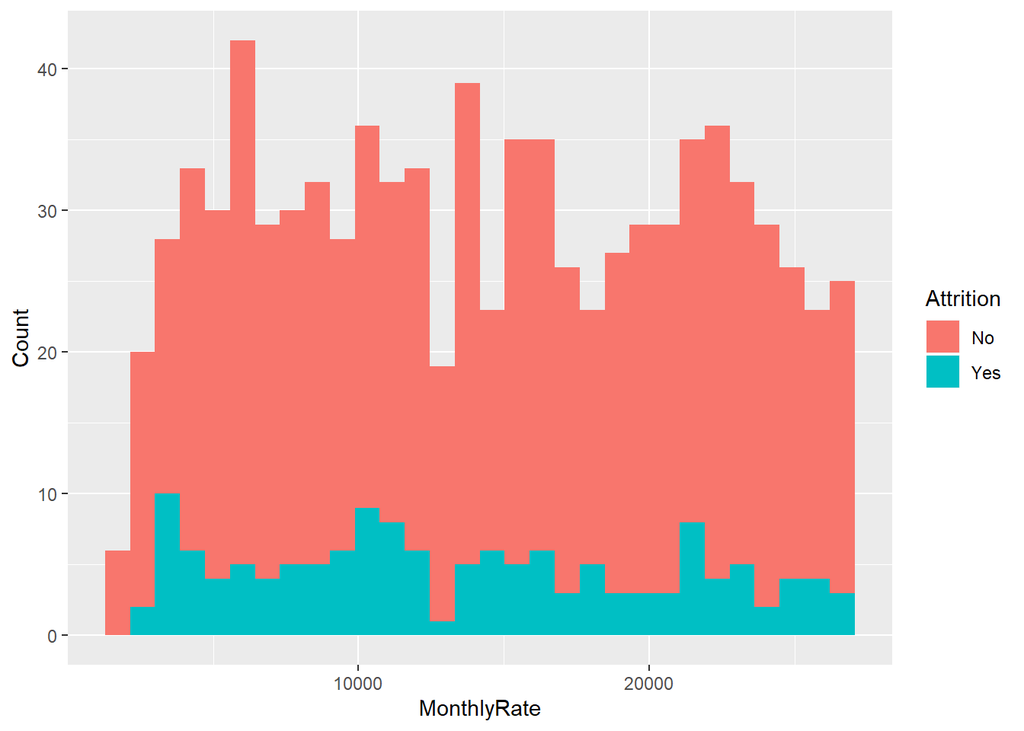

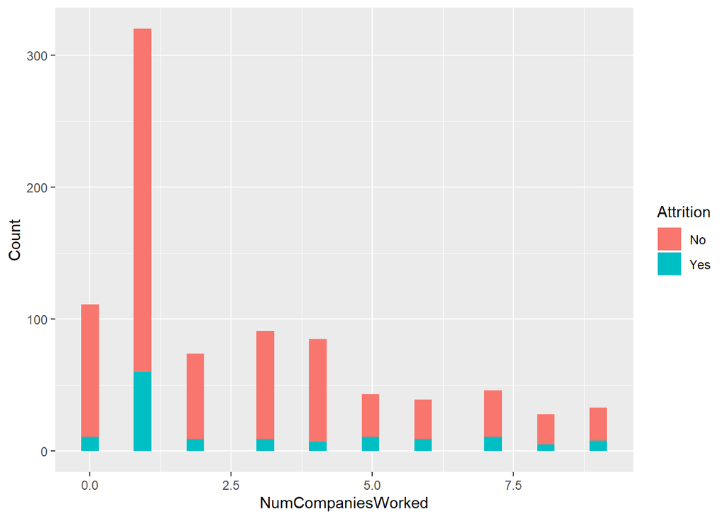

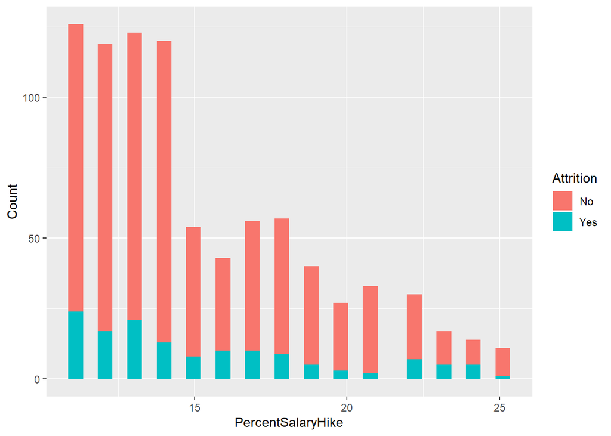

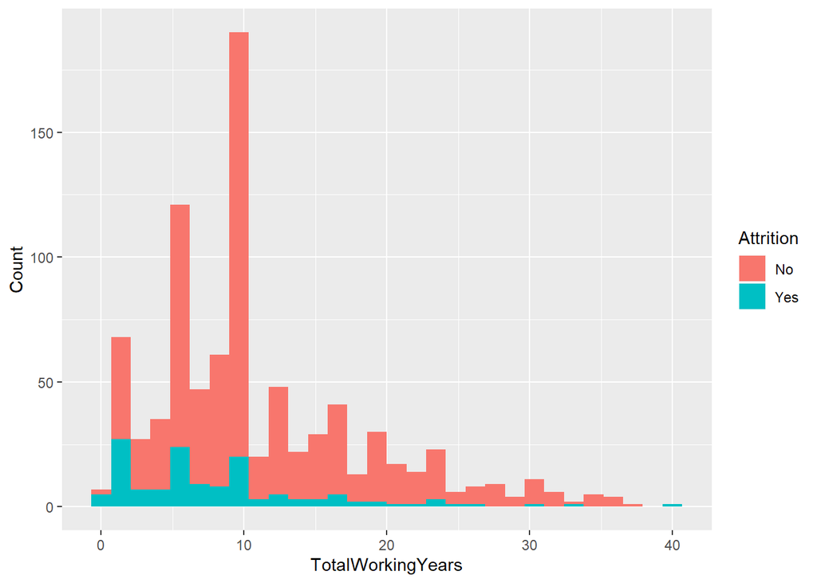

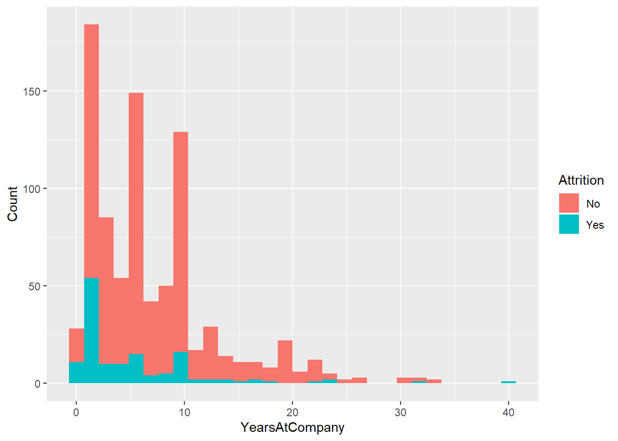

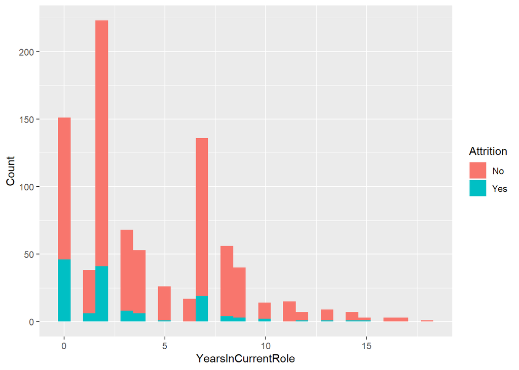

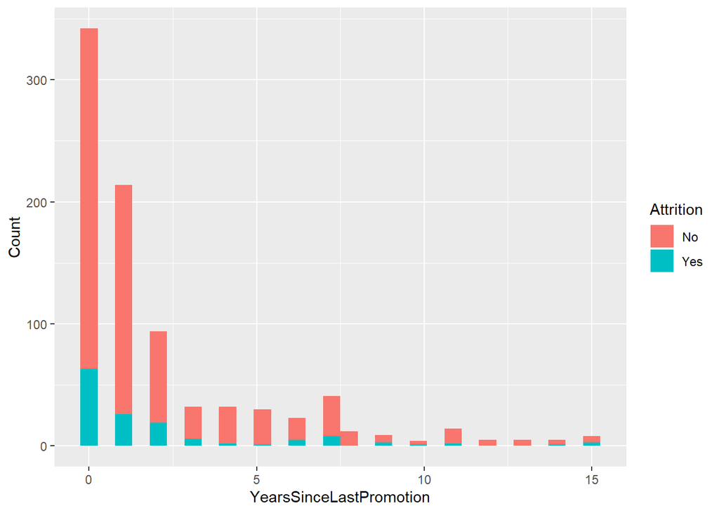

[1 more figures not shown]

Based on the above histograms, we infer that the following variables potentially influence the attrition: Age (high attrition for less than 25), TotalWorkingYears (high attrition for less than 5), YearsAtCompany (high attrition for 0), YearsInCurrentRole (high attrition for 0), YearsWithCurrManager (high attrition for 0).

Now, we will convert string factors into integer factors and look at the correlation coefficients.

```
##               Attribute    Estimate      p.value
## 1              OverTime  0.27203659 3.164202e-16
## 2         MaritalStatus  0.19701495 4.620847e-09
## 3        JobInvolvement -0.18779341 2.393172e-08
## 4     TotalWorkingYears -0.16720612 7.058845e-07
## 5              JobLevel -0.16213644 1.529785e-06
## 6    YearsInCurrentRole -0.15621571 3.665017e-06
## 7         MonthlyIncome -0.15491496 4.421756e-06
## 8                   Age -0.14938358 9.657758e-06
## 9      StockOptionLevel -0.14868030 1.064537e-05
## 10 YearsWithCurrManager -0.14678224 1.381421e-05
## 11       YearsAtCompany -0.12875406 1.400387e-04
## 12      JobSatisfaction -0.10752094 1.492881e-03
## 13              JobRole  0.09053860 7.536574e-03
## 14      WorkLifeBalance -0.08978971 8.050071e-03
## 15     DistanceFromHome  0.08713629 1.013034e-02
```

From the histograms, we have identified potential grouping of some of the variables that may result in higher correlation. Lets add a few derived group variables and re-look at the correlation coefficients.

```
##                    Attribute   Estimate      p.value
## 1                   OverTime  0.2720366 3.164202e-16
## 2     TotalWorkingYearsGroup -0.2057122 9.095043e-10
## 3  YearsWithCurrManagerGroup -0.2013061 2.091082e-09
## 4              MaritalStatus  0.1970150 4.620847e-09
## 5             JobInvolvement -0.1877934 2.393172e-08
## 6    YearsInCurrentRoleGroup -0.1792353 1.024982e-07
## 7          TotalWorkingYears -0.1672061 7.058845e-07
## 8                   JobLevel -0.1621364 1.529785e-06
## 9         YearsInCurrentRole -0.1562157 3.665017e-06
## 10             MonthlyIncome -0.1549150 4.421756e-06
## 11                       Age -0.1493836 9.657758e-06
## 12          StockOptionLevel -0.1486803 1.064537e-05
## 13      YearsWithCurrManager -0.1467822 1.381421e-05
## 14                  AgeGroup -0.1409388 3.019880e-05
## 15            YearsAtCompany -0.1287541 1.400387e-04
```

Now, let’s use GGPairs to assess collinearity of some of these top variables.

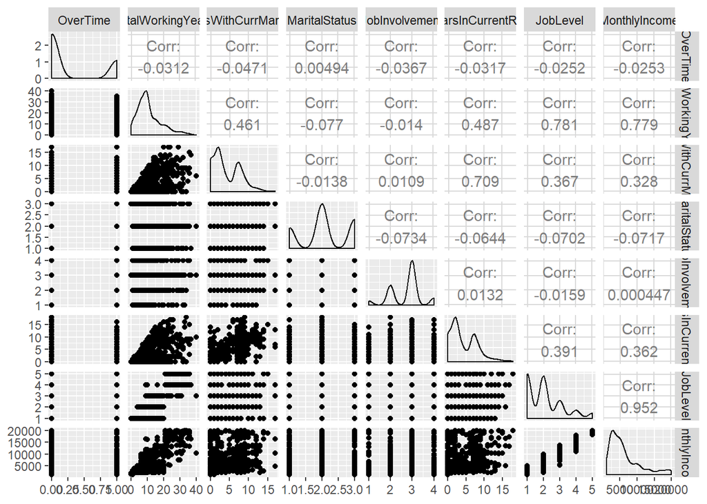

From the above plot, we can infer that the following variables have high correlation. It is enough if we include one of these variables in the model.

- JobLevel, TotalWorkingYears, MonthlyIncome
- YearsWithCurrManager, YearsInCurrentRole

Next up, we will assess the models based on specific sets of the top variables.

## Classification Model for Attrition

First, we will assess a few kNN models using hyperparameter tuning, and look at the mean accuracy, sensitivity, and specificity metrics to compare them.

kNN Model 1 - “OverTime”, “TotalWorkingYearsGroup”, “MaritalStatus”

```
##     k  Accuracy Sensitivity Specificity
## 13 13 0.8522605   0.9836034   0.1467819
```

kNN Model 2 - “OverTime”, “JobInvolvement”, “MaritalStatus”

```
##     k  Accuracy Sensitivity Specificity
## 10 10 0.8450575   0.9736132   0.1700766
```

kNN Model 3 - “OverTime”, “TotalWorkingYears”, “MaritalStatus”

```
##     k  Accuracy Sensitivity Specificity
## 13 13 0.8530268   0.9833449   0.1557246
```

kNN Model 4 - “OverTime”, “YearsWithCurrManagerGroup”, “MaritalStatus”

```
##   k  Accuracy Sensitivity Specificity
## 6 6 0.8462835   0.9823882   0.1553161
```

kNN Model 5 - “OverTime”, “YearsWithCurrManager”, “MaritalStatus”

```
##   k Accuracy Sensitivity Specificity
## 7 7 0.855249   0.9825408   0.1954856
```

The kNN models give us good accuracy and sensitivity metrics. However, these models are failing to meet the criteria of at least 60% of specificity requirement. Let us explore Naive Bayes models now.

Naive Bayes Model 1 - “OverTime”, “TotalWorkingYearsGroup”, “MaritalStatus”

```
##        Seed    Accuracy Sensitivity Specificity
##  50.5000000   0.8306513   0.8718446   0.4796088
```

Naive Bayes Model 2 - “OverTime”, “JobInvolvement”, “MaritalStatus”

```
##        Seed    Accuracy Sensitivity Specificity
##  50.5000000   0.8478927   0.8635297   0.5820551
```

Naive Bayes Model 3 - “OverTime”, “TotalWorkingYears”, “MaritalStatus”

```
##        Seed    Accuracy Sensitivity Specificity
##  50.5000000   0.8539464   0.8713415   0.6291760
```

Naive Bayes Model 4 - “OverTime”, “YearsWithCurrManagerGroup”, “MaritalStatus”

```
##        Seed    Accuracy Sensitivity Specificity
##  50.5000000   0.8470498   0.8670088   0.5951530
```

Naive Bayes Model 5 - “OverTime”, “YearsWithCurrManager”, “MaritalStatus”

```
##        Seed    Accuracy Sensitivity Specificity
##  50.5000000   0.8501533   0.8681159   0.5874116
```

Based on the above comparisions, the Naive Bayes model with OverTime, TotalWorkingYears, and MaritalStatus gives us a robust model for predicting Attrition that meets our criteria of at least 60% of sensitivity and specificity. We will proceed with this model, obtain predictions for the validation dataset, and export the predictions in required format.